# Exploratory Analysis

Connor Kirkpatrick

26 September 2016

```r
#What was the largest claim?
max(expenses2015$`Amount Claimed`)
```

```
## [1] 20097
```

```r
# Did it match the largest amount paid?
max(expenses2015$`Amount Paid`)
```

```
## [1] 20097
```

```r
#Vector of whether the amount claimed equals the amount paid
ac_to_ap <- expenses2015$`Amount Claimed` == expenses2015$`Amount Paid`

#ratio of rejected expenses
mean(ac_to_ap)
```

```
## [1] 0.9987823
```

```r
table(ac_to_ap)
```

```
## ac_to_ap
##  FALSE   TRUE
##    216 177173
```

```r
rejected <- subset(expenses2015, !ac_to_ap)
mean(rejected$`Amount Claimed`)
```

```
## [1] 90.95639
```

```r
#reasons why they weren't paid
levels(rejected$`Reason If Not Paid`)
```

```
## [1] "Duplicate Claim"       "Insufficient Evidence" "Not Under Scheme"
## [4] "Over 90 Days"          "Withdrawn MP Request"  "Wrong Expense Categ."
```

```r
#Stats
table((rejected$`Reason If Not Paid`))
```

```
##
##       Duplicate Claim Insufficient Evidence      Not Under Scheme
##                     2                    42                   138
##          Over 90 Days  Withdrawn MP Request  Wrong Expense Categ.
##                    22                     2                     2
```

```r
table(expenses2015$`Reason If Not Paid`)
```

```
##
##       Duplicate Claim Insufficient Evidence      Not Under Scheme
##                     2                    46                   148
##          Over 90 Days  Withdrawn MP Request  Wrong Expense Categ.
##                    22                     2                     2
```

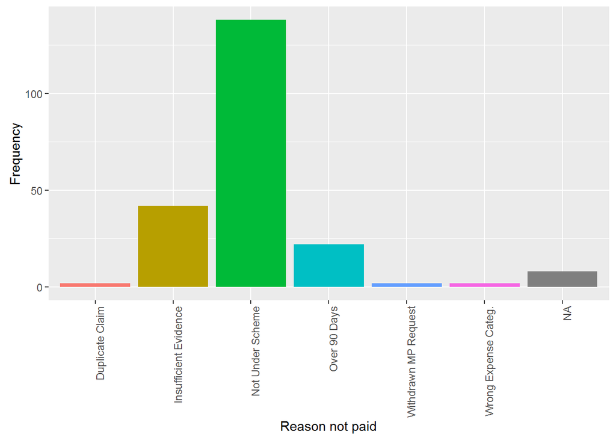

```r
ggplot(rejected) + geom_bar(aes(x = rejected$`Reason If Not Paid`, fill = rejected$`Reason If Not Paid` )) + labs(x = "Reason not paid", y = "Frequency", fill = NULL) + theme(axis.text.x = element_text(angle = 90, hjust = 1), legend.position = "none")
```

```r
by_mp <- group_by(expenses2015, `MP's Name`)
total_by_mp <- summarise(by_mp, count = n(),
                total_claimed = sum(`Amount Claimed`))

ototal_by_mp <- arrange(total_by_mp, desc(total_claimed))

top10 <- slice(ototal_by_mp, 1:10)
kable(top10, format = "markdown")
```

| MP’s Name | count | total_claimed |
| --- | --- | --- |
| Stewart McDonald | 409 | 97395.64 |
| Joanna Cherry | 377 | 96578.33 |
| Michelle Thomson | 461 | 92230.74 |
| Paul Monaghan | 1038 | 90003.89 |
| Angus MacNeil | 636 | 89054.37 |
| Steven Paterson | 803 | 88650.78 |
| Alex Salmond | 364 | 84889.63 |
| Tommy Sheppard | 366 | 84338.65 |
| Karl McCartney | 402 | 82209.58 |
| Corri Wilson | 555 | 81818.16 |

# Further Developments

- What do these MP’s have in common?
- Who claimed the most dodgy expenses?
- Use genderizeR to predict Gender on the names?

## The basics

In this section, we will find the following statistics about our data:

- Max Expense Claimed
- Minimum Expense Claimed
- Mean Expense Claimed

To find the Max expense claimed, we can use the `max` function.

Before we do that however, let’s make a quick helper function to print the numbers nicely as a currency

Note that an alternative way (probably better) would be to create a “currency” class, and then creat a print.currency method that would automatically be called when our currency class was printed.

```r
#Convert to Pounds

# Takes a numeric and returns a string of the value in the format £X,XXX.XX

con_to_pounds <- function(value, pence = T){
    if(pence == T){
        n_small <-  2
    }else{
        n_small <-  0
    }
    paste("£", format(value, digits=10, nsmall=n_small, decimal.mark=".", big.mark=","), sep = "")
}
```

Now that we have our helper function, let’s try it out.

```r
max_claimed <- max(expenses2015$`Amount Claimed`)

formatted_max_claimed <- con_to_pounds(max_claimed)

whoclaimedmax <- which.max(expenses2015$`Amount Claimed`)

most_expensive_claim <- expenses2015[whoclaimedmax,]

kable(most_expensive_claim, format = "markdown")
```

| Year | Date | Claim No. | MP’s Name | MP’s Constituency | Category | Expense Type | Short Description | Details | Journey Type | From | To | Travel | Nights | Mileage | Amount Claimed | Amount Paid | Amount Not Paid | Amount Repaid | Status | Reason If Not Paid |
| --- | --- | --- | --- | --- | --- | --- | --- | --- | --- | --- | --- | --- | --- | --- | --- | --- | --- | --- | --- | --- |
| 15_16 | 2015-04-01 | 431940 | Jim Dowd | Lewisham West and Penge BC | Office Costs | Const Office Rent | Office Costs | 1/4/15 - 31/3/16 | NA | NA | NA | NA | NA | NA | 20097 | 20097 | 0 | 0 | Paid | NA |

So we can see that Jim Dowd had the largest claim (of £20,097.00!). We can see this was for “Const Office Rent”

Let’s now do the same for the smallest expense claimed.

```r
minclaimed <- min(expenses2015$`Amount Claimed`)
who_claimed_min <- which.min(expenses2015$`Amount Claimed`)
#least_expensive_claim <- expenses2015[who_claimed_min] commented out as it is broken
```

It seems we’ve hit an error. The smallest amount claimed is in fact a negative number! We should investigate to see what is happening here.

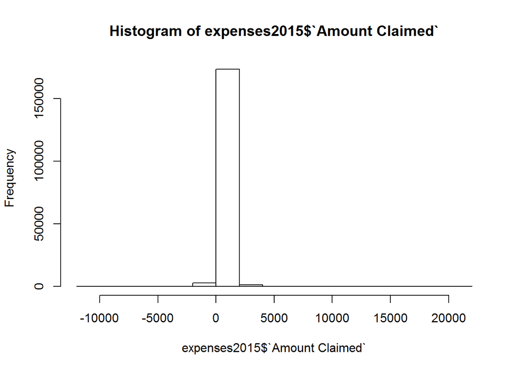

```r
hist(expenses2015$`Amount Claimed`)
```

```r
table(expenses2015$`Amount Claimed` < 0)
```

```
##
##  FALSE   TRUE
## 175515   1874
```

So there are currently 1874 expenses which have an `Amount Claimed` value of less than 0. Let’s filter for these and have a deeper look.

```r
negative_claims <- filter(expenses2015, `Amount Claimed` < 0)
kable(head(select(negative_claims, c(2:5, 16:17))))
```

| Date | Claim No. | MP’s Name | MP’s Constituency | Amount Claimed | Amount Paid |
| --- | --- | --- | --- | --- | --- |
| 2015-07-09 | 485651 | Bill Esterson | Sefton Central CC | -30.00 | -30.00 |
| 2015-05-18 | 485719 | Mark Prisk | Hertford and Stortford CC | -9.90 | -9.90 |
| 2016-01-15 | 503935 | Rory Stewart | Penrith and The Border CC | -67.00 | -67.00 |
| 2016-03-06 | 504671 | Dan Jarvis | Barnsley Central BC | -9.90 | -9.90 |
| 2015-06-22 | 485756 | Marion Fellows | Motherwell and Wishaw BC | -78.30 | -78.30 |
| 2016-03-22 | Payment To Supplier | Christina Rees | Neath CC | -8.69 | -8.69 |

Looking at the claims, we can see that they look like genuine expenses, but with a negative sign in front of them. So possible explanations could be:

- Error in the data. To fix, we could just remove the “-” sign.
- These may be correct expenses. We’d need to investigate the context for these further if that was the case.

Having emailed IPSA (who provded the data), it appears that these negative expenses arise when an MP has been refunded for an expense claimed, and so in turn has the expense refunded.

An easy solution would be to filter out these negative values, as they’re not relevant to what we’re looking at currently.

- We could investigate the refunded expenses to see if there is a pattern to them that differs from normal expenses.
- We could in fact use these expenses to find their original claim, and then remove both.

For now, let’s just keep it simple and filter out the negative values

```r
expenses2015postive <- filter(expenses2015, `Amount Claimed` > 0)

#Alternatively for our purposes, we could have just used expenses2015[expenses2015$`Amount Claimed` >= 0]
```

Now let’s try again to find the smallest claim made

```r
minclaimed <- min(expenses2015postive$`Amount Claimed`)
who_claimed_min <- which.min(expenses2015postive$`Amount Claimed`)

least_expensive_claim <- expenses2015postive[who_claimed_min,]


kable(least_expensive_claim)
```

| Year | Date | Claim No. | MP’s Name | MP’s Constituency | Category | Expense Type | Short Description | Details | Journey Type | From | To | Travel | Nights | Mileage | Amount Claimed | Amount Paid | Amount Not Paid | Amount Repaid | Status | Reason If Not Paid |
| --- | --- | --- | --- | --- | --- | --- | --- | --- | --- | --- | --- | --- | --- | --- | --- | --- | --- | --- | --- | --- |
| 15_16 | 2016-02-29 | 493217 | David Lammy | Tottenham BC | Staffing | Food & Drink Volunteer | Allie Expenses Jan-March | Lunch | NA | NA | NA | NA | NA | NA | 0.01 | 0.01 | 0 | 0 | Paid | NA |

## The average claim?

In this section, we will find the value of the average claim. We’ll also find the top 5 Expense types for approved and non approved claims.

### Mean Claim and Mean Paid

```r
mean_claimed <- mean(expenses2015postive$`Amount Claimed`)
mean_paid <- mean(expenses2015postive$`Amount Paid`)

con_to_pounds(mean_claimed) # con_to_pounds clearly isn't perfect, as it's printing too many sig figs
```

```
## [1] "£155.3801039"
```

```r
con_to_pounds(mean_paid) # same here
```

```
## [1] "£155.2734003"
```

### Most common expense categories

```r
common_expense_types <- expenses2015postive %>%
                        group_by(Category) %>%
                        dplyr::summarise(count = n(),
                                         sum = con_to_pounds(sum(`Amount Claimed`)),
                                        mean_claim = con_to_pounds(mean(`Amount Claimed`)))


arrange(common_expense_types, desc(count))[1:5,]
```

```
## # A tibble: 5 × 4
##        Category count            sum   mean_claim
##          <fctr> <int>          <chr>        <chr>
## 1        Travel 92394  £4,645,719.66 £50.28161634
## 2  Office Costs 57885 £11,593,849.11  £200.291079
## 3 Accommodation 11441  £7,252,998.08 £633.9479136
## 4      Staffing  7190  £1,882,715.52 £261.8519499
## 5    Winding Up  2699    £684,615.49  £253.655239
```

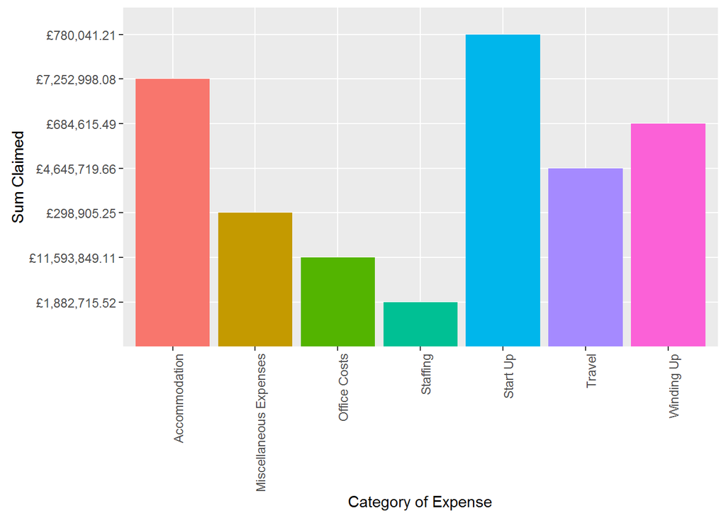

```r
ggplot(common_expense_types) + geom_bar(aes(x = Category, y = sum, fill = Category), stat = "identity") +labs(x = "Category of Expense", y = "Sum Claimed", fill = NULL) + theme(axis.text.x = element_text(angle = 90, hjust = 1), legend.position = "none")
```

```r
# Convert this to filter for rejected claims. Search for categories/types of reject reasons

common_rejected_expense_types <- expenses2015 %>%
                                 filter(Status == "Not Paid") %>%
                                  group_by(Category) %>%
                                  dplyr::summarise(count = n(),
                                                 sum = con_to_pounds(sum(`Amount Claimed`)),
                                                mean_claim = con_to_pounds(mean(`Amount Claimed`)))


kable(arrange(common_rejected_expense_types, desc(count))[1:5,])
```

| Category | count | sum | mean_claim |
| --- | --- | --- | --- |
| Travel | 76 | £3,091.21 | £40.67381579 |
| Office Costs | 70 | £3,818.43 | £54.549 |
| Accommodation | 32 | £2,581.95 | £80.6859375 |
| Winding Up | 18 | £1,860.11 | £103.3394444 |
| Miscellaneous Expenses | 6 | £271.43 | £45.23833333 |

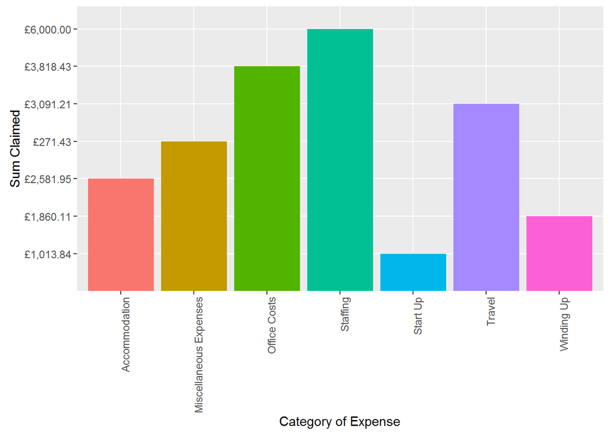

```r
ggplot(common_rejected_expense_types) + geom_bar(aes(x = Category, y = sum, fill = Category), stat = "identity") +labs(x = "Category of Expense", y = "Sum Claimed", fill = NULL) + theme(axis.text.x = element_text(angle = 90, hjust = 1), legend.position = "none")
```

# Time Analysis

## Does the average expense claim vary across the months of the Year?

To do this, we will use the `lubridate` library (good thing we loaded it earlier!).

```r
expenses_by_month <- expenses2015 %>%
                        filter(`Amount Claimed` > 0) %>%
                        group_by(month(Date))


summary_expenses_by_month <- summarise(expenses_by_month , `Number of Claims` = n(), `Sum of Claims` = con_to_pounds(sum(`Amount Claimed`)))

kable(summary_expenses_by_month)
```

| month(Date) | Number of Claims | Sum of Claims |
| --- | --- | --- |
| 1 | 16492 | £2,231,316.08 |
| 2 | 15348 | £2,007,652.17 |
| 3 | 15002 | £2,301,538.70 |
| 4 | 5726 | £1,556,192.80 |
| 5 | 12241 | £2,018,453.71 |
| 6 | 18525 | £3,504,957.17 |
| 7 | 17286 | £2,950,989.74 |
| 8 | 10498 | £1,841,558.17 |
| 9 | 15533 | £2,200,607.58 |
| 10 | 16453 | £2,182,333.03 |
| 11 | 17764 | £2,238,791.74 |
| 12 | 13793 | £2,104,453.43 |

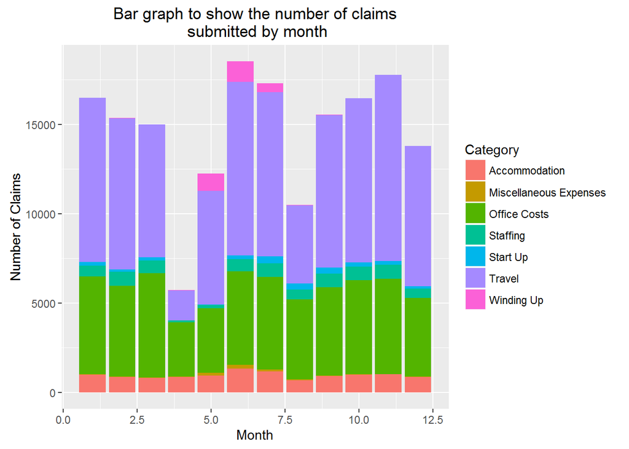

```r
ggplot(expenses_by_month) + geom_bar(aes(x = month(Date), fill = Category)) + labs(x = "Month", y = "Number of Claims", title = "Bar graph to show the number of claims\n submitted by month")
```

Things to notice

- The number of accomodation claims stays roughly constant across the month, with a slight peak in June, and a dip in August.
- MP’s Travel claims have a huge decease in April (and a slighlty less dramatic dip in August)
- Claims for winding up are submitted between May and August.

Let’s make the same graph, but displaying the sum of the claims instead.

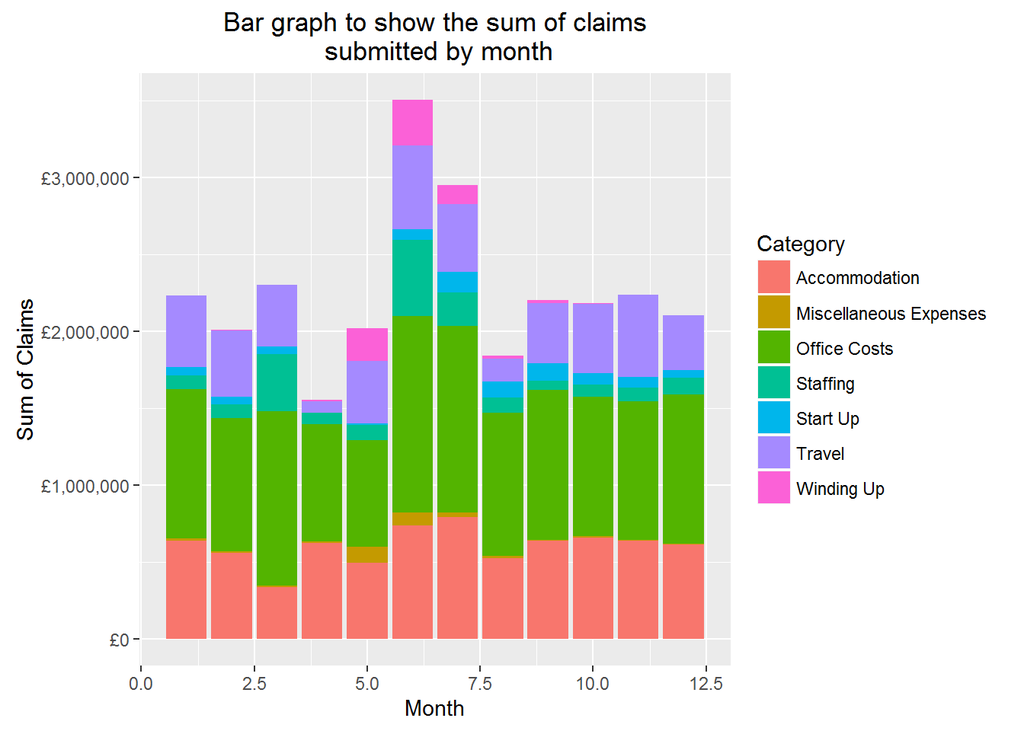

```r
ggplot(expenses_by_month) + geom_bar(aes(x = `month(Date)`, weight = `Amount Claimed`, fill = Category)) + labs(x = "Month", y = "Sum of Claims", title = "Bar graph to show the sum of claims\n submitted by month") + scale_y_continuous(labels = scales::dollar_format(suffix = "", prefix = "£"))
```

# Who is the cheekiest MP?

Let’s see how many rejected expenses each MP had.

*To do*

- Invesitgate how many rejected invoices there were.
- What(&Freq) categories were these?
- Investigate expenses !(Paid OR Not Paid) *Filter to remove MP’s with few, small claims.* Freq of rejected claims with any other factors?

```r
reject_expenses <- expenses2015 %>%
                      filter(Status == "Not Paid") %>%
                    group_by(`MP's Name`)


cheeky_mps <- summarise(reject_expenses, Freq = n(), Sum = (sum(`Amount Claimed`)))

cheekiest_mps <- filter(cheeky_mps, `Freq` > 2 | `Sum` > 1000)

cheekiest_mps <- droplevels(cheekiest_mps)$`MP's Name`



kable(arrange(cheeky_mps, desc(Freq))[1:10,])
```

| MP’s Name | Freq | Sum |
| --- | --- | --- |
| Alan Meale | 18 | 62.81 |
| Peter Kyle | 12 | 1542.11 |
| Brendan O’Hara | 8 | 365.24 |
| Heather Wheeler | 8 | 65.70 |
| Angus Robertson | 7 | 605.01 |
| Angus MacNeil | 6 | 312.30 |
| Geoffrey Cox | 6 | 8.95 |
| Laurence Robertson | 6 | 13.20 |
| Anne McIntosh | 5 | 409.48 |
| Norman Baker | 5 | 36.03 |

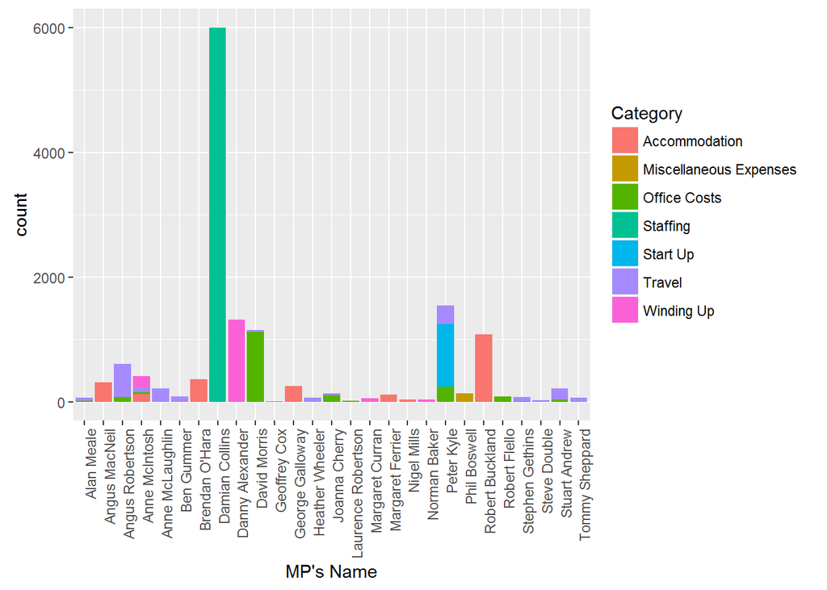

```r
ggplot(subset(reject_expenses, `MP's Name` %in% cheekiest_mps), aes(x = `MP's Name`, weight = `Amount Claimed`, fill = Category)) + geom_bar() +
      theme(axis.text.x = element_text(angle = 90,
                                       hjust = 1))
```

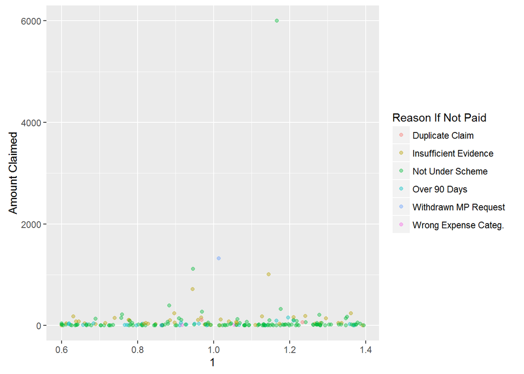

```r
ggplot(reject_expenses) + geom_jitter(aes( x = 1, y = `Amount Claimed`, col = `Reason If Not Paid`), alpha = 0.4)
```